# Predicting Wine Ratings with Machine Learning

by Jas Beausejour

January 15th, 2019

## Dataset

In this report, we will be using a dataset created by *zackthoutt* which can easily be downloaded from **Kaggle** at this link.

To ensure that this code runs on a standalone basis, I include code that downloads the dataset into the user’s temporary files from my GitHub repository.

```r
# First, I load some libraries to ensure that everything runs smoothly.
if(!require(tidyverse)) install.packages("tidyverse", repos = "http://cran.us.r-project.org")
if(!require(caret)) install.packages("caret", repos = "http://cran.us.r-project.org")
if(!require(knitr)) install.packages("knitr", repos = "http://cran.us.r-project.org")
if(!require(kableExtra)) install.packages("kableExtra", repos = "http://cran.us.r-project.org")
library(tidyverse)
library(caret)
library(knitr)
library(kableExtra)
# Now, I create a temporary file
dl <- tempfile()
# Here, we download the dataset in its raw format from my GitHub repository
download.file("https://raw.githubusercontent.com/jasbeausejour/Wine_Project/master/Data/winemag-data-130k-v2.csv",dl)
```

We can now read the file into the R environment.

```r
ratings <- read.csv(dl,
                      sep = ",",
                      fill = TRUE)
```

Let us now define our dataset.

```r
dim(ratings)
```

```
[1] 129971     14
```

| Variables | Description |
| --- | --- |
| X | Identifier |
| country | Country of origin of the wine |
| description | The full text of the review written by the taster |
| designation | The vineyard within the winery where the grapes that made the wine are from |
| points | The number of points WineEnthusiast rated the wine on a scale of 1-100 (though they say they only post reviews for wines that score >=80) |
| price | The cost for a bottle of the wine |
| province | The province or state that the wine is from |
| region_1 | The wine growing area in a province or state (ie Napa) |
| region_2 | Sometimes there are more specific regions specified within a wine growing area (ie Rutherford inside the Napa Valley), but this value can sometimes be blank |
| taster_name | Name of the taster |
| taster_twitter_handle | Twitter Handle of the taster |
| title | The title of the wine review |
| variety | The type of grapes used to make the wine (ie Pinot Noir) |
| winery | The winery that made the wine |

## Data Exploration

**Points**

As we are primarly interested about the points given to each wine, let us first examine the distribution of points.

Let’s first look at a few statistics:

```r
ratings %>% select(points) %>%
  summarize(Min=min(points),
            Max=max(points),
            Average=round(mean(points),2),
            Median=round(median(points),2),
            "Standard Deviation"=round(sd(points),2)) %>%
  kable(caption = "Points Statistics", align = rep("c",5)) %>%
  kable_styling(full_width = FALSE)
```

Points Statistics

| Min | Max | Average | Median | Standard Deviation |
| --- | --- | --- | --- | --- |
| 80 | 100 | 88.45 | 88 | 3.04 |

We can get a better understanding of the distribution by looking at a histogram.

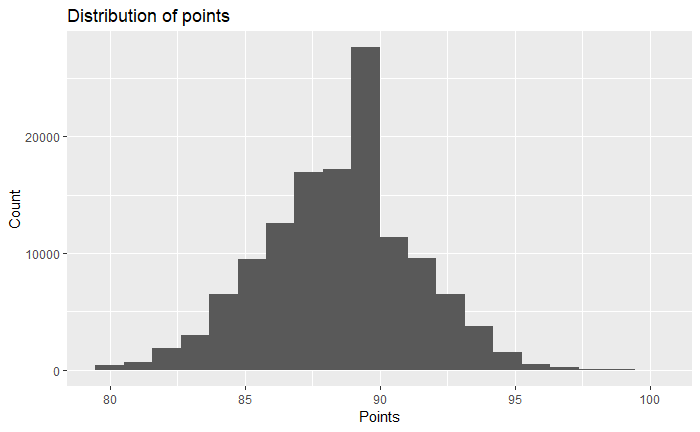

```r
ratings %>% select(points) %>%
  ggplot(aes(points)) +
  geom_histogram(bins = 20)+
  labs(title="Distribution of points", x="Points", y="Count")
```

```r
NA
```

We can check if the data is normally distributed with this code:

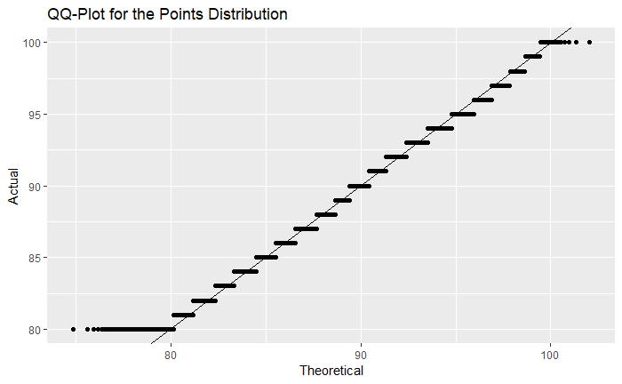

```r
ratings %>% ggplot(aes(sample=points)) +
  geom_qq(dparams=summarize(ratings, mean=mean(points), sd=sd(points))) +
  geom_abline() + labs(title="QQ-Plot for the Points Distribution", y="Actual", x="Theoretical")
```

We see from this plot that, although the data starts at 80 points and ends at 100 points, the normal distribution is a relatively good estimate between those two end points.

**Country**

Let us now turn our attention to which countries are represented.

We can compute how many different countries are represented.

```r
length(unique(ratings$country))
```

```
[1] 44
```

We can make a bar plot showing the number of reviews by country like this (for the top 10).

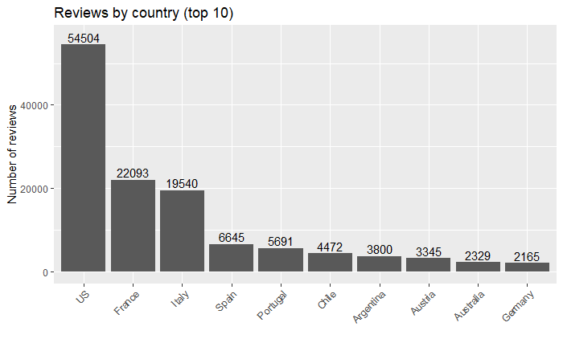

```r
ratings %>% group_by(country) %>% summarize(n=n()) %>% top_n(10,wt=n) %>%
  ggplot(aes(x=reorder(country,-n),y=n)) +
  geom_bar(stat="identity")+
  geom_text(aes(label=n),nudge_y = 1800)+
  labs(title="Reviews by country (top 10)", y="Number of reviews", x="")+
  theme(axis.text.x = element_text(angle = 45, hjust = 1))
```

We see that this is a very US-centric dataset, with about 42% of the reviews.

We can also have a quick look at the distribution of scores by country. We notice that Austria and Germany have very high median scores and that Spain and Chile take the bottom two spots in the top 10 countries with most reviews. Additionally, in the top 10, we notice that only 5 countries have a review of 100 points: Australia, France, Italy, Portugal and the US.

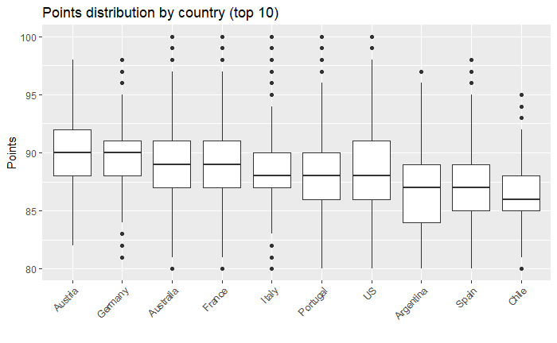

```r
top_10_countries <- ratings %>% group_by(country) %>% summarize(n=n()) %>% top_n(10,wt=n) %>% .$country
ratings %>% filter(country %in% top_10_countries) %>%
  ggplot(aes(x=reorder(country,-points,FUN = median), y=points)) +
  geom_boxplot()+
  labs(title="Points distribution by country (top 10)", y="Points", x="")+
  theme(axis.text.x = element_text(angle = 45, hjust = 1))
```

**Province**

Most of the time, however, knowing the country of a wine isn’t sufficient to determine what to expect. For instance, a Côte-du-Rhone from France can be expected to taste very different from a Bordeaux or a Burgundy.

Let us see which *provinces* are the most prevalent in our data.

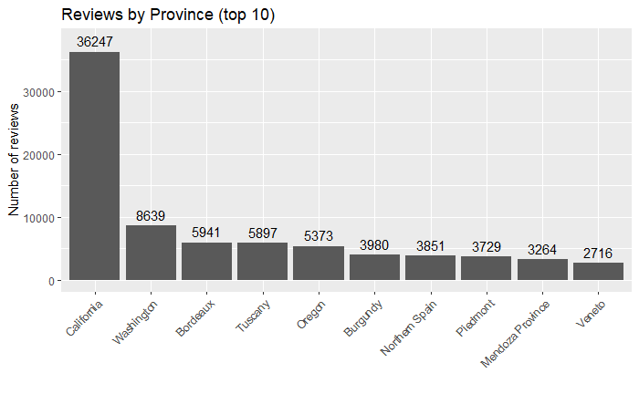

```r
ratings %>% group_by(province) %>% summarize(n=n()) %>% top_n(10,wt=n) %>%
  ggplot(aes(x=reorder(province,-n),y=n)) +
  geom_bar(stat="identity")+
  geom_text(aes(label=n),nudge_y = 1800)+
  labs(title="Reviews by Province (top 10)", y="Number of reviews", x="")+
  theme(axis.text.x = element_text(angle = 45, hjust = 1))
```

Again, we notice how skewed our data is towards the US, with California in particular. Within California, we see Napa, Russian River Valley, Paso Robles and Sonoma have a very strong showing. Weirdly enough, “California” appear again in this variable.

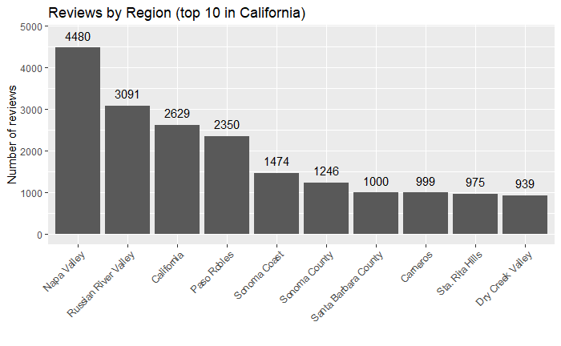

```r
ratings %>% filter(province=="California") %>%
  group_by(region_1) %>% summarize(n=n()) %>% top_n(10,wt=n) %>%
  ggplot(aes(x=reorder(region_1,-n),y=n)) +
  geom_bar(stat="identity")+
  geom_text(aes(label=n),nudge_y = 300)+
  labs(title="Reviews by Region (top 10 in California)", y="Number of reviews", x="")+
  theme(axis.text.x = element_text(angle = 45, hjust = 1))
```

Back to the whole dataset, let’s examine the score distribution by province for the top 10.

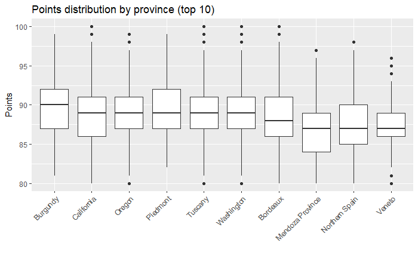

```r
top_10_province <- ratings %>% group_by(province) %>% summarize(n=n()) %>% top_n(10,wt=n) %>% .$province
ratings %>% filter(province %in% top_10_province) %>%
  ggplot(aes(x=reorder(province,-points,FUN = median), y=points)) +
  geom_boxplot()+
  labs(title="Points distribution by province (top 10)", y="Points", x="")+
  theme(axis.text.x = element_text(angle = 45, hjust = 1))
```

**Variety**

We can compute how many different grape varietals are represented.

```r
length(unique(ratings$variety))
```

```
[1] 708
```

To the untrained eye, 708 may seem like a lot, but let us remember that there are approximately 10,000 grape varietals in the world. Of course, not all of them are frequently found in wine. Let’s look at the top 12 varieties.

```r
ratings %>%
  group_by(variety) %>%
  summarize(Reviews=n()) %>%
  top_n(12,Reviews) %>%
  arrange(desc(Reviews)) %>%
  select(Variety=variety,Reviews=Reviews) %>%
  kable(align = rep("c",2)) %>%
  kable_styling(full_width = FALSE)
```

| Variety | Reviews |
| --- | --- |
| Pinot Noir | 13272 |
| Chardonnay | 11753 |
| Cabernet Sauvignon | 9472 |
| Red Blend | 8946 |
| Bordeaux-style Red Blend | 6915 |
| Riesling | 5189 |
| Sauvignon Blanc | 4967 |
| Syrah | 4142 |
| RosÃ© | 3564 |
| Merlot | 3102 |
| Nebbiolo | 2804 |
| Zinfandel | 2714 |

We notice that the most common variety are Pinot Noir, Chardonnay and Cabernet Sauvignon. This is not surprising as those grapes are very common in the US. We then see “Red Blend” and “Bordeaux-style Red Blend”. The former is a bit dissapointing as Red Blend could litteraly mean anything. Let’s see where those wines come from:

```r
ratings %>% filter(variety=="Red Blend") %>%
  group_by(country) %>%
  summarize(Reviews =n()) %>%
  select(Country=country,Reviews=Reviews) %>%
  top_n(5,Reviews) %>%
  arrange(desc(Reviews)) %>%
  kable(align = rep("c",2)) %>%
  kable_styling(full_width = FALSE)
```

| Country | Reviews |
| --- | --- |
| Italy | 3624 |
| US | 2972 |
| Spain | 818 |
| Chile | 409 |
| France | 304 |

We are a bit surprised that Italy would have so many “Red Blends” since there are many *appelations* that would have made the data more specific. However, we are not surprised to see the US high on this list given the flexibility of winemaking regulations in the country.

For wines of the old world, France for instance, we expect to see specific blends. For instance, all wines in Bordeaux would have some concentration of Cabernet Sauvignon, Cabernet Franc and Merlot, and perhaps a bit of Petit Verdot. Let’s see.

```r
ratings %>% filter(province=="Bordeaux") %>%
  group_by(variety) %>%
  summarize(Reviews=n()) %>%
  select(Variety=variety,Reviews) %>%
  top_n(5,Reviews) %>%
  arrange(desc(Reviews)) %>%
  kable(align = rep("c",2)) %>%
  kable_styling(full_width = FALSE)
```

| Variety | Reviews |
| --- | --- |
| Bordeaux-style Red Blend | 4617 |
| Bordeaux-style White Blend | 951 |
| RosÃ© | 191 |
| Merlot | 72 |
| Sauvignon Blanc | 68 |

Our intuition is confirmed.

Let us now look at the top 10 varieties and their score distribution.

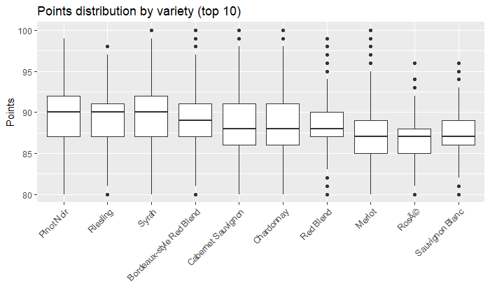

```r
top_10_varieties <- ratings %>% group_by(variety) %>% summarize(n=n()) %>% top_n(10,wt=n) %>% .$variety
ratings %>% filter(variety %in% top_10_varieties) %>%
  ggplot(aes(x=reorder(variety,-points,FUN = median), y=points)) +
  geom_boxplot()+
  labs(title="Points distribution by variety (top 10)", y="Points", x="")+
  theme(axis.text.x = element_text(angle = 45, hjust = 1))
```

**Taster**

The next variable we will examine is who exactly wrote the review. This information is held in the **taster_name** variable.

There are 20 unique values in this variable, one of which is the absence of the rater’s name. We will exclude those observations in the following analysis.

Let us see who was most prolific.

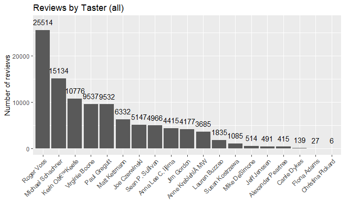

```r
ratings %>% filter(taster_name != "") %>% group_by(taster_name) %>% summarize(n=n()) %>%
  ggplot(aes(x=reorder(taster_name,-n),y=n)) +
  geom_bar(stat="identity")+
  geom_text(aes(label=n),nudge_y = 1800)+
  labs(title="Reviews by Taster (all)", y="Number of reviews", x="")+
  theme(axis.text.x = element_text(angle = 45, hjust = 1))
```

We can appreciate that Roger Voss, Michael Schadner and Kerin O’Keefe have a very strong contribution to the dataset. Especially Mr. Voss… that is a lot of wine.

Let us look now at a distribution of score by taster. We will only use the top 10 at this stage.

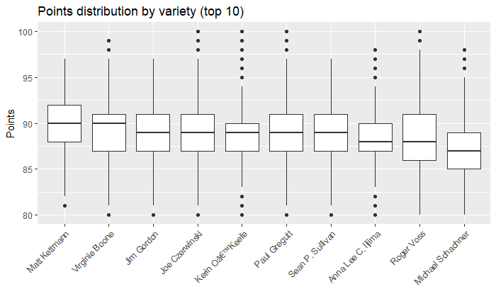

```r
top_10_taster <- ratings %>% filter(taster_name!="") %>% group_by(taster_name) %>% summarize(n=n()) %>% top_n(10,wt=n) %>% .$taster_name
ratings %>% filter(taster_name %in% top_10_taster) %>%
  ggplot(aes(x=reorder(taster_name,-points,FUN = median), y=points)) +
  geom_boxplot()+
  labs(title="Points distribution by variety (top 10)", y="Points", x="")+
  theme(axis.text.x = element_text(angle = 45, hjust = 1))
```

From this graph, we can see that some tasters tend to grade wines higher (like Matt Kettmann), and others more hasrshly (like Roger Voss and Michael Schachner).

**Winery**

We know that some wineries have a very strong reputation and tend to systematically attract more points. Let us look at the distribution of the average score by winery.

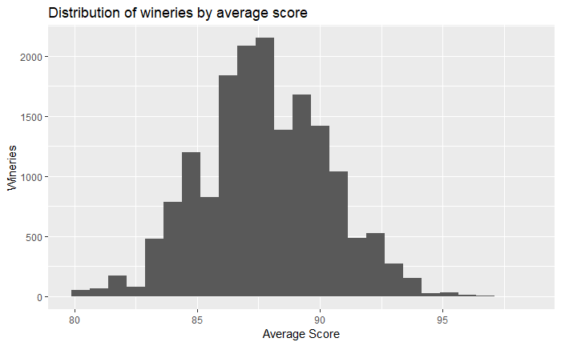

```r
ratings %>% group_by(winery) %>% summarize(Avg=mean(points)) %>%
  ggplot(aes(Avg)) +
  geom_histogram(bins=25)+
  labs(title="Distribution of wineries by average score", y="Wineries", x="Average Score")
```

Of course, it is possible that some of the extreme cases here are wineries that are only seldom reviewed. The average number of review per winery is:

```r
ratings %>% group_by(winery) %>% summarise(n=n()) %>% ungroup() %>% summarise(Average=mean(n)) %>% .$Average
```

```
[1] 7.756221
```

```r
ratings %>% group_by(winery) %>%
  summarise(Avg=mean(points),Reviews=n(), Price = round(mean(price),2)) %>%
  filter(Avg>95 & Reviews>=8) %>% arrange(-Avg) %>%
  select(Winery=winery, `Average Score`=Avg, Reviews = Reviews, `Average Bottle Price`=Price) %>%
  kable(align = rep("c",3)) %>%
  kable_styling(full_width = F)
```

| Winery | Average Score | Reviews | Average Bottle Price |
| --- | --- | --- | --- |
| Tenuta dell'Ornellaia | 96.70000 | 10 | 286.50 |
| Château Léoville Barton | 95.66667 | 9 | NA |
| Wayfarer | 95.33333 | 18 | 111.67 |
| Mascarello Giuseppe e Figlio | 95.20000 | 10 | 174.30 |
| Horsepower | 95.09091 | 11 | 116.82 |

**Price**

Finally, let us look at the price variable, which is the only numerical variable we have at our disposal, thus far, to build our model. Let’s look at a distribution.

```r
ratings %>% filter(price != "") %>%
  summarize(Min=min(price),
            Max=max(price),
            Average=round(mean(price),2),
            Median=round(median(price),2),
            "Standard Deviation"=round(sd(price),2)) %>%
  kable(caption = "Price Statistics", align = rep("c",5)) %>%
  kable_styling(full_width = FALSE)
```

Price Statistics

| Min | Max | Average | Median | Standard Deviation |
| --- | --- | --- | --- | --- |
| 4 | 3300 | 35.36 | 25 | 41.02 |

We can build a histogram to get a better view.

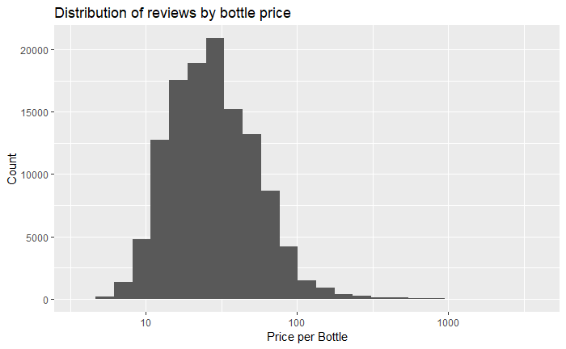

```r
ratings %>% filter(price != "") %>%
  ggplot(aes(price)) +
  geom_histogram(bins=25)+
  scale_x_log10()+
  labs(title="Distribution of reviews by bottle price", y="Count", x="Price per Bottle")
```

Now, the question on everyone’s lip is whether there is a correlation between price and quality (points). Let’s look at a scatterplot.

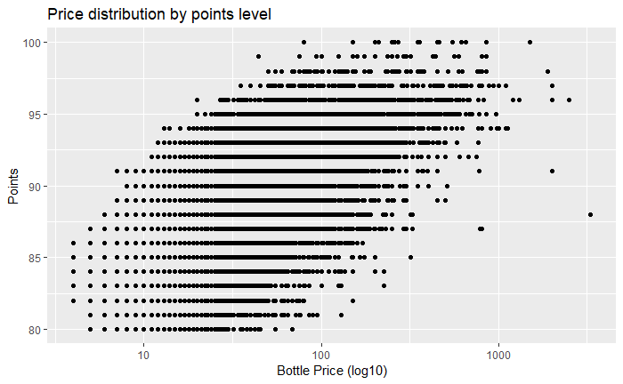

```r
ratings %>% filter(price !="") %>%
  ggplot(aes(x=price,y=points))+
  geom_point()+
  scale_x_log10()+
  labs(title="Price distribution by points level", y="Points", x="Bottle Price (log10)")
```

We can see from this graph that there does seem to be a slight correlation, with most of the very low scores in the low-end of the price range. We also notice how, as we go up in points, we tend to shift to the right ot the price range.

To better understand this phenomenon, let’s look at the average price at each point level.

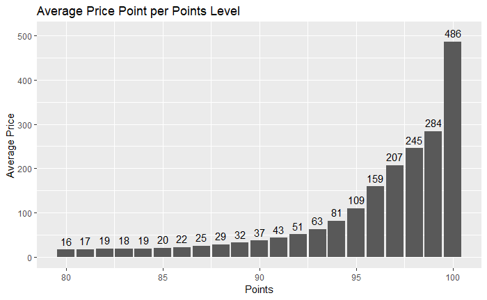

```r
ratings %>% filter(price != "") %>% group_by(points) %>%
  summarise(`Average Price`=mean(price)) %>%
  ggplot(aes(x=points, y=`Average Price`)) +
  geom_bar(stat = "identity")+
  geom_text(aes(label=round(`Average Price`)),nudge_y = 20)+
  labs(title="Average Price Point per Points Level", x="Points")
```

Here, we clearly see that bottles over and above 90 points tend to be much more expensive. On average, bottles with 95+ points cost more than $100. Only very expensive bottles receive 100 points.

**Title and Vintage**

From the title of the review, we are often able to extract the vintage of the wine that was tasted. Let us try to do this systematically.

```r
year_pattern <- "\\d\\d\\d\\d"
ratings <- ratings %>% mutate(Vintage = as.numeric(str_extract(title,year_pattern)))
# Remove anything that could be an error. We will assume that no wine in the dataset was made before 1910.
ratings$Vintage <-  ifelse(ratings$Vintage>2018,"",ratings$Vintage)
ratings$Vintage <-  ifelse(ratings$Vintage<1910,"",ratings$Vintage)
# Create decades to make visualization easier
ratings <- ratings %>%
  mutate(Decade =
           ifelse(ratings$Vintage %in% 1900:1909, "1900s",
           ifelse(ratings$Vintage %in% 1910:1919, "1910s",
           ifelse(ratings$Vintage %in% 1920:1929, "1920s",
           ifelse(ratings$Vintage %in% 1930:1939, "1930s",
           ifelse(ratings$Vintage %in% 1940:1949, "1940s",
           ifelse(ratings$Vintage %in% 1950:1959, "1950s",
           ifelse(ratings$Vintage %in% 1960:1969, "1960s",
           ifelse(ratings$Vintage %in% 1970:1979, "1970s",
           ifelse(ratings$Vintage %in% 1980:1989, "1980s",
           ifelse(ratings$Vintage %in% 1990:1999, "1990s",
           ifelse(ratings$Vintage %in% 2000:2009, "2000s",
           ifelse(ratings$Vintage %in% 2010:2019, "2010s",
                  "")))))))))))))
```

Let’s now look at this new variable:

```r
ratings %>% filter(Decade != "") %>% group_by(Decade) %>%
  summarise(Reviews = n(), `Average Score`=round(mean(points),2)) %>%
  kable(align = rep("c",3)) %>%
  kable_styling(full_width = FALSE)
```

| Decade | Reviews | Average Score |
| --- | --- | --- |
| 1910s | 9 | 89.89 |
| 1920s | 8 | 88.12 |
| 1930s | 2 | 93.50 |
| 1940s | 3 | 93.67 |
| 1950s | 3 | 95.33 |
| 1960s | 12 | 94.17 |
| 1970s | 5 | 90.80 |
| 1980s | 28 | 90.86 |
| 1990s | 1661 | 87.99 |
| 2000s | 37896 | 88.24 |
| 2010s | 85566 | 88.60 |

Although earlier decades seem to display higher scores, this is likely due to the fact that there are only a few reviews for these years, of very good bottles.

For curiosity, let’s look at the average score for the region of Bordeaux for the years 2005+. For any one with wine knowledge, the results won’t be surprising: 2009, 2008 and 2010 are very high on the list. I must say that 2015 being second to last is unexpected however.

```r
ratings %>% filter(Vintage>2005 & province=="Bordeaux") %>%
  group_by(Vintage) %>%
  summarize("Average Score"=round(mean(points),2), Reviews = n()) %>%
  arrange(-`Average Score`) %>%
  kable(align = rep("c",3)) %>%
  kable_styling(full_width = F)
```

| Vintage | Average Score | Reviews |
| --- | --- | --- |
| 2009 | 90.18 | 473 |
| 2008 | 89.75 | 287 |
| 2010 | 89.40 | 733 |
| 2006 | 89.14 | 272 |
| 2007 | 88.94 | 179 |
| 2014 | 88.73 | 966 |
| 2012 | 88.67 | 824 |
| 2011 | 88.17 | 726 |
| 2013 | 87.85 | 506 |
| 2015 | 87.26 | 525 |
| 2016 | 86.64 | 218 |

### Descriptions and Natural Language Processing

In the following section, we will dive into the content of the **description** variable, which contains the text of the review written by the tasters. We will use tecniques of text mining and natural language processing inspired by the tutorial posted by Debbie Liske at [this ling](https://www.datacamp.com/community/tutorials/R-nlp-machine-learning).

First, let us load some more libraries.

```r
if(!require(gridExtra)) install.packages("gridExtra", repos = "http://cran.us.r-project.org")
if(!require(tidytext)) install.packages("tidytext", repos = "http://cran.us.r-project.org")
if(!require(wordcloud2)) install.packages("wordcloud2", repos = "http://cran.us.r-project.org")
if(!require(circlize)) install.packages("circlize", repos = "http://cran.us.r-project.org")
if(!require(yarrr)) install.packages("yarrr", repos = "http://cran.us.r-project.org")
if(!require(udpipe)) install.packages("udpipe", repos = "http://cran.us.r-project.org")
library(gridExtra)
library(tidytext)
library(wordcloud2)
library(circlize)
library(yarrr)
library(udpipe)
```

We now create a quick function to get rid of English contractions

```r
fix.contractions <- function(doc) {
  # "won't" is a special case as it does not expand to "wo not"
  doc <- gsub("won't", "will not", doc)
  doc <- gsub("can't", "can not", doc)
  doc <- gsub("n't", " not", doc)
  doc <- gsub("'ll", " will", doc)
  doc <- gsub("'re", " are", doc)
  doc <- gsub("'ve", " have", doc)
  doc <- gsub("'m", " am", doc)
  doc <- gsub("'d", " would", doc)
  # 's could be 'is' or could be possessive: it has no expansion
  doc <- gsub("'s", "", doc)
  return(doc)
}
```

Let’s apply it, and convert everything to lower case.

```r
ratings$description <- sapply(ratings$description,fix.contractions)
ratings$description <- tolower(ratings$description)
```

The first thing we can look at is the lenght of the descriptions.

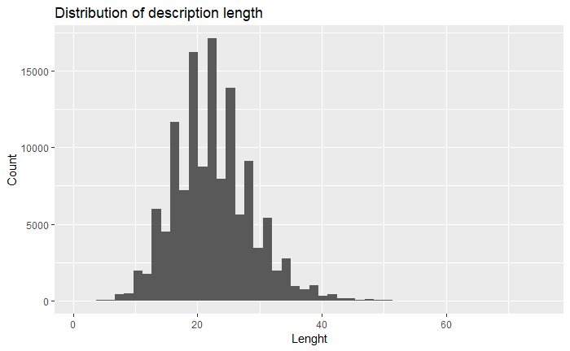

```r
length_of_decription <- description_words_filtered %>% group_by(X) %>% summarise(Length=n())
length_of_decription %>% ggplot(aes(x=Length))+
  geom_histogram(bins=50)+
  labs(title="Distribution of description length",x="Lenght",y="Count")
```

Let us see if there seems to be a relationship between the length of the descriptions and the points.

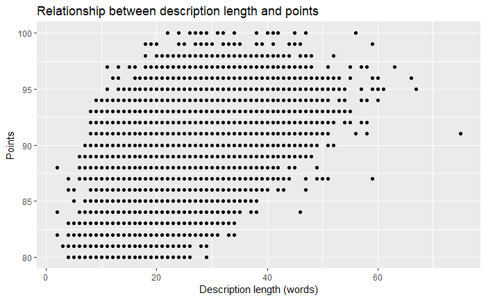

```r
ratings <- ratings %>% left_join(length_of_decription,by = "X")
ratings %>% ggplot(aes(x=Length,y=points))+
  geom_point()+
  labs(title="Relationship between description length and points", x="Description length (words)", y="Points")
```

As we can see in this graph, there seems to be a tendency to witness longer descriptions for bottles with higher points.

```r
description_words_filtered %>% group_by(word) %>%
  summarise(Count=n()) %>%
  arrange(desc(Count)) %>%
  write.csv(file="common_words.csv")
```